# Visualizing Pittsburgh

Allison Zhang

Pittsburgh, Pennsylvania is known to be an up and coming city in the United States. Because of its livability and its low prices, many people are moving to Pittsburgh. This is also true because of Pittsburgh’s colleges that are known nationwide, such as Carnegie Mellon University and University of Pittsburgh. These factors are allowing it becoming a hot spot for big companies, specifically Google and Uber. Because of this large influx in population, the demographics are constantly changing, leading to interesting trends that might not have existed before. There are many different trends that are interesting and could be explored, but here are three trends that I explored which might be a surprise to many people who don’t know much about the city of bridges.

## 1. Travel Time

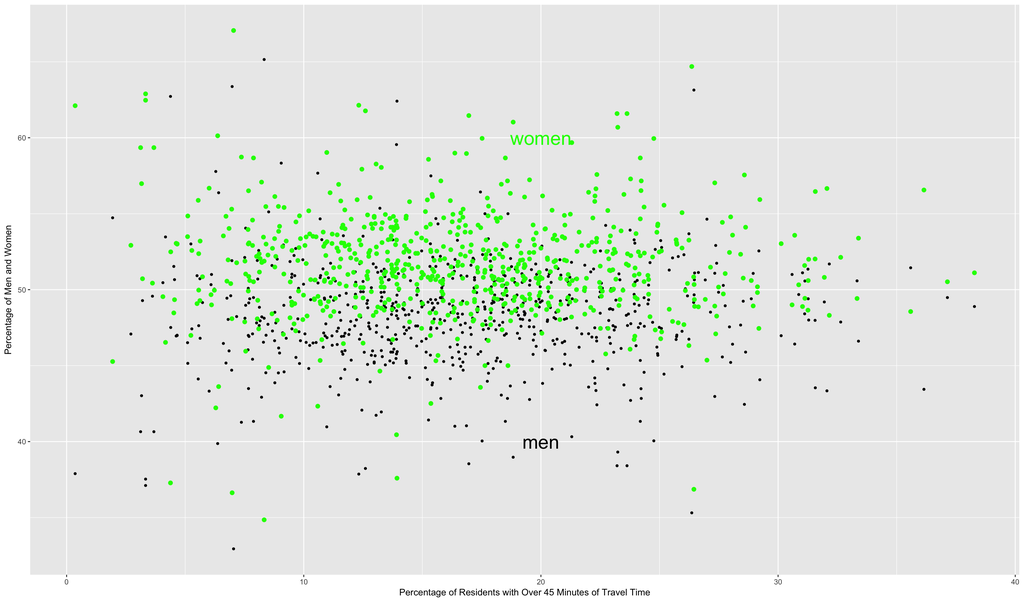

## 2. Race Segregation

As seen in most cities, Pittsburgh also has predominantly white, Asian, and African American communities. This visualization focuses on the African American populations in Pittsburgh. As you can tell, there is one densely populated area in Pittsburgh that has the largest percentage population of African Americans. From my knowledge of Pittsburgh, this would be Wilkinsburg. Wilkinsburg is on the outskirts of the city, and was founded when it became a railroad stop in the 1850s, bringing many workers into Pittsburgh (Wilkinsburg). This is the time when many African Americans flooded into Pittsburgh, settling in what’s now known as Wilkinsburg Borough. There is also a larger amount of African Americans in downtown Pittsburgh. This is probably caused by the large amount of jobs in downtown Pittsburgh, leading to the increase of not only African Americans, but a larger population overall. The history of Pittsburgh helps show its current demographics, including who currently resides in all communities across the city.

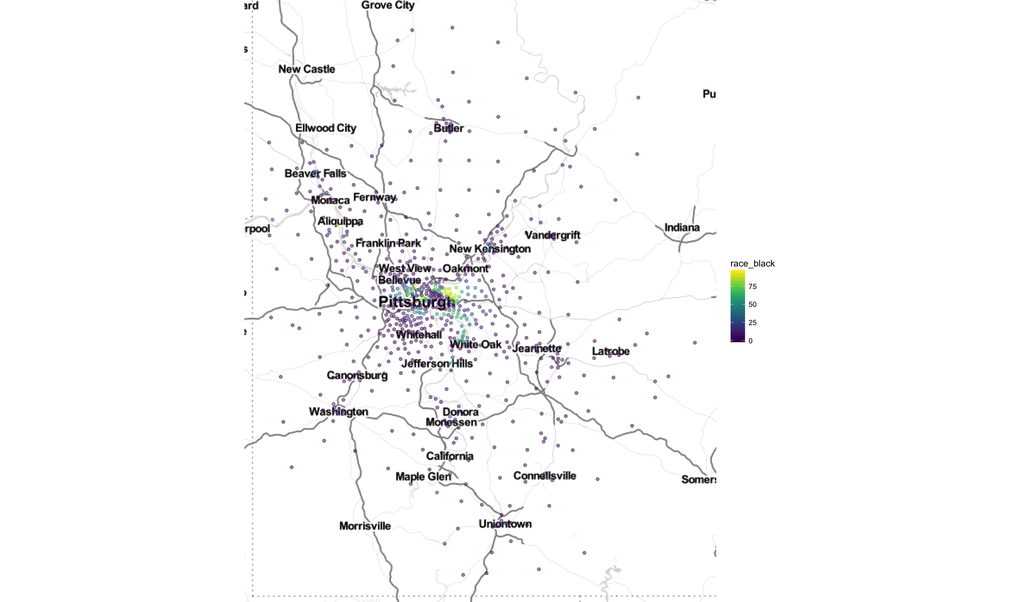

## 3. Paying Rent

There was also a trend between households with income less than forty thousand dollars and the median amount of rent they pay. As expected, most of these households payed a small median rent, mostly under 1000 dollars. However, there was a small percentage paying much more for their median rent, paying up to 2500 dollars. A reason for this may be housing subsidies for individuals with very low income, or if their spouse or family member had a higher income and paid for the housing. An obvious pattern is shown here, but it isn’t linear. This shows that it is more common for most people with income less than 40 thousand dollars to pay less rent. This is also shown by the highlighted box, which you can see has the most amount of points in it in the entire graph, showing the trend. This pattern is something that most people would expect, but would still find interest in knowing.

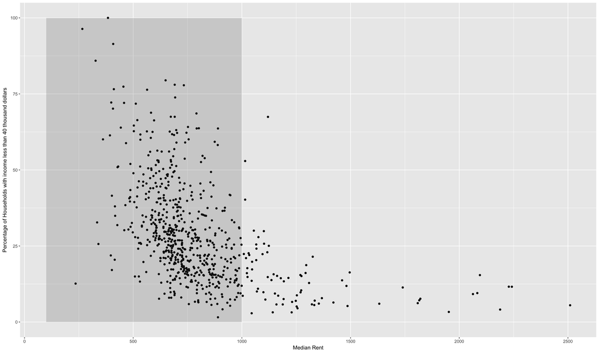

## Conclusion

Pittsburgh is known for its technology, its food, and its livability, but often people forget about the demographics that define Pittsburgh. These few graphs are just a small look into the people of Pittsburgh, but never forget that there are many more factors that make cities the way they are today.

## References

Byham, Tacy. “It’s Not about Men vs. Women in the Workplace.” Pittsburgh Post-Gazette, PG Publishing Co, 27 Aug. 2017, www.post-gazette.com/opinion/Op-Ed/2017/08/27/Gender-diversity-is-not-about-men-vs-women-in-the-workplace/stories/201708270016.

“History.” Borough of Wilkinsburg, www.wilkinsburgpa.gov/about-wilkinsburg/history/.

Kellow, Gracie. “Fact Check: Are Men Really More Aggressive Drivers?” All the Rage, 15 Mar. 2016, blog.uwgb.edu/alltherage/fact-check-are-men-really-more-aggressive-drivers/.